# Experiment: oogonia released temp, do, light

Chelsey Wegener

9/29/2020

Since I’m suggesting that oogonia release is affected by pH and salinity, here I am showing that other factors (such as temperature, dissovled oxygen, or light) are not significant in this interaction. To do this I’m doing simple regressions. y-axis will be average oogonia released per unit (calculted the same as the salinity pH graph) and the x-axis will be the average temperature, dissolved oxygen or light. Currently I’m not sure what “light” data to use (loggers?) to I’m just doing temperature and dissolved oxygen. I will need to update this.

Convert to number

```r
exp$oo_disc_1<-as.numeric(exp$oo_disc_1)
exp$oo_disc_2<-as.numeric(exp$oo_disc_2)
exp$oo_disc_3<-as.numeric(exp$oo_disc_3)
exp$oo_disc_4<-as.numeric(exp$oo_disc_4)

exp$unit_temp_hach<-as.numeric(exp$unit_temp_hach)
exp$unit_do_hach<-as.numeric(exp$unit_do_hach)
exp$treatment<-as.character(exp$treatment)
```

Average oogonia per thalli

```r
exp$avg_oo<-rowMeans(exp[,c('oo_disc_1', 'oo_disc_2', 'oo_disc_3','oo_disc_4')], na.rm=TRUE)
```

Let’s subset the data per run

```r
r1<-subset(exp, run=='1')
r2<-subset(exp, run=='2')
r3<-subset(exp,run=='3')
```

Average oogonia, temperature, and dissolved oxygen. Oogonia average= average of oogonia on discs in one unit, and then the average of these averages for each treatment. Temperature and do average=average of all temperature or do hach readings in the unit per treatment.

```r
tapply(r1$treatment, r1$avg_oo, mean)
```

[output not shown]

```r
r1ooav<-aggregate( avg_oo ~ treatment,r1, mean)

tapply(r2$treatment, r2$avg_oo, mean)
```

[output not shown]

```r
r2ooav<-aggregate( avg_oo ~ treatment,r2, mean)

tapply(r3$treatment, r3$avg_oo, mean)
```

[output not shown]

```r
r3ooav<-aggregate( avg_oo ~ treatment,r3, mean)


tapply(r1$treatment, r1$unit_temp_hach, mean)
```

```
## 15.4 15.6 15.8 15.9   16 16.1 16.2 16.3 16.4 16.5 16.6 16.7 16.8 16.9   17 17.4
##   NA   NA   NA   NA   NA   NA   NA   NA   NA   NA   NA   NA   NA   NA   NA   NA
## 17.5
##   NA
```

```r
r1tempav<-aggregate( unit_temp_hach ~ treatment,r1, mean)

tapply(r2$treatment, r2$unit_temp_hach, mean)
```

```
## 14.5 14.6 14.7 14.8
##   NA   NA   NA   NA
```

```r
r2tempav<-aggregate( unit_temp_hach ~ treatment,r2, mean)

tapply(r3$treatment, r3$unit_temp_hach, mean)
```

```
## 14.9   15 15.1 15.2 15.3 15.4 15.5 15.6 15.7 15.8 15.9   16 16.1 16.2
##   NA   NA   NA   NA   NA   NA   NA   NA   NA   NA   NA   NA   NA   NA
```

```r
r3tempav<-aggregate( unit_temp_hach ~ treatment,r3, mean)


tapply(r1$treatment, r1$unit_do_hach, mean)
```

[output not shown]

```r
r1doav<-aggregate( unit_do_hach ~ treatment,r1, mean)

tapply(r2$treatment, r2$unit_do_hach, mean)
```

```
## 10.52 10.67 10.68 10.72 10.74 10.75 10.77 10.78  10.8 10.82 10.83 10.84 10.85
##    NA    NA    NA    NA    NA    NA    NA    NA    NA    NA    NA    NA    NA
## 10.86 10.93 10.94 10.95    11 11.05
##    NA    NA    NA    NA    NA    NA
```

```r
r2doav<-aggregate( unit_do_hach ~ treatment,r2, mean)

tapply(r3$treatment, r3$unit_do_hach, mean)
```

[output not shown]

```r
r3doav<-aggregate( unit_do_hach ~ treatment,r3, mean)
```

Add run number back to dataframes. Probably not neccesary, more of a check

```r
r1tempav$run<-'1'
r2tempav$run<-'2'
r3tempav$run<-'3'
```

Combine to make new data frame

```r
r1complete<-cbind(r1ooav, r1tempav, r1doav)
r2complete<-cbind(r2ooav, r2tempav, r2doav)
r3complete<-cbind(r3ooav, r3tempav, r3doav)

final<-rbind(r1complete, r2complete, r3complete)
```

Linear equation

```r
lm_eqn_temp <- function(final){
    m <- lm(avg_oo ~ unit_temp_hach, final);
    eq <- substitute(italic(avg_oo) == a + b %.% italic(unit_temp_hach)*","~~italic(r)^2~"="~r2,
         list(a = format(unname(coef(m)[1]), digits = 2),
              b = format(unname(coef(m)[2]), digits = 2),
             r2 = format(summary(m)$r.squared, digits = 3)))
    as.character(as.expression(eq));
}

lm_eqn_do <- function(final){
    m <- lm(avg_oo ~ unit_do_hach, final);
    eq <- substitute(italic(avg_oo) == a + b %.% italic(unit_do_hach)*","~~italic(r)^2~"="~r2,
         list(a = format(unname(coef(m)[1]), digits = 2),
              b = format(unname(coef(m)[2]), digits = 2),
             r2 = format(summary(m)$r.squared, digits = 3)))
    as.character(as.expression(eq));
}
```

Removing redundant column

```r
new<-final[-c(1)]
```

Graph temperature or dissolved oxygen on the x-axis, average oogonia on the y.

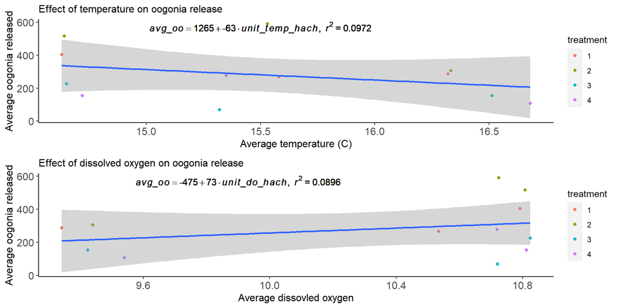

```r
temp_graph<-ggplot(data = new, mapping = aes(x = unit_temp_hach, y = avg_oo)) + geom_point(aes(colour = treatment)) +geom_smooth(method=lm)+ geom_text(x = 15.5, y = 570, label = lm_eqn_temp(final), parse = TRUE)+ ggtitle("Effect of temperature on oogonia release")+ theme(plot.title = element_text(size = 12, face = "plain")) +theme(axis.text=element_text(size=12),axis.title=element_text(size=12,face="plain")) + ylab("Average oogonia released") + xlab("Average temperature (C)") + theme(panel.grid.major = element_blank(), panel.grid.minor = element_blank(), panel.background = element_blank(), axis.line = element_line(colour = "black"))

do_graph<-ggplot(data = new, mapping = aes(x = unit_do_hach, y = avg_oo)) + geom_point(aes(colour = treatment)) +geom_smooth(method=lm)+ geom_text(x = 9.9, y = 570, label = lm_eqn_do(final), parse = TRUE)+ ggtitle("Effect of dissolved oxygen on oogonia release")+ theme(plot.title = element_text(size = 12, face = "plain")) +theme(axis.text=element_text(size=12),axis.title=element_text(size=12,face="plain")) + ylab("Average oogonia released") + xlab("Average dissovled oxygen") + theme(panel.grid.major = element_blank(), panel.grid.minor = element_blank(), panel.background = element_blank(), axis.line = element_line(colour = "black"))

ggarrange(temp_graph, do_graph, ncol=1, nrow=2)
```